# Business Report

# EXECUTIVE SUMMARY

The main **objective** of this report is to **provide information to our client Mark Peterson about wine ratings** and whether it is a suitable business for him to invest in. In addition to this, more practical insights are provided regarding Wine and its origin, price, variety and ratings.

Report includes **the dataset with 130,000 observations of wine and 14 different variables per each observation** which is considered sufficient for analysing and predicting the outcomes.

**Business problem** refers to **the prediction of wine quality based on different characteristics of wine**.

**Outcomes of Descriptive Analysis:**

We have found out that the top-5 wine-producing countries are *the US, France, Italy, Spain and Portugal*. Along with this, information about most reviewed wine varieties is also provided in this report. As per the graphical representation,the relation b/w Price of a wine bottle and no. of awarded points is **positive** because of the upward slope of the line.

**Model Accuracy:**

**Model 1** that is build to predict wine ratings (in points) by knowing the price, wine variety and country using Linear Regression Model turned out to be **not accurate** since its p-value varies from one country to another plus its residual values are also far from being near zero.

## ———————————————————————————————————————-

# INTRODUCTION

The term **Wine** has taken significant place in the market nowadays. All the consumers, wine producers, writers, editors, bloggers, restaurants use a specific rating criteria to decide which wine to purchase and which wine to leave on the shelf. Experiments on wine production have been carried out and it is found that taste of wine is affected by various factors such as water, temperature,vnature of soil,vvweather,vmineral compositions etc.,hence wine production is pretty difficult and time-consuming process since wine acquires a specific taste only after its maturity which usually takes up to 20 years of time period. That is why, *older the wine is, more expensive it becomes*. So, its important for stakeholders to get a better understanding of wine market influencing factors before making any business decisions.

In this report, main focus is being made on the different varieties of wine and its ratings depending upon various factors such as price, country of origin,grape type and many more.

**CASE STUDY**- Mark Peterson is an investor and entrepreneur who is seeking an opportunity to invest in fine wines. He wants to customize his wine investment portfolio, but doesn’t have much experience with wine. He would like to know which countries to buy wines from, how to choose well-performing wines, wine varieties, etc.

## ———————————————————————————————————————-

# BUSINESS PROBLEM

This report will provide an insight about whether the quality of wine can be predicted from its characteristics or not and if we can predict wine quality(in points).

*Major Question*: Can we predict the quality of a wine based on its characteristics?

**Sub-questions**:

Q1. Can we predict wine ratings (in points) by knowing the price, wine variety and country?

Q2. Can we predict a country based on the type of wine grape and average rating of wine produced in that country?

## ———————————————————————————————————————-

# ABOUT THE DATASET [Wine Ratings]

The dataset consists of almost 130,000 wine review entries. Each entry contains 14 variables including the country of origin, the description of the wine, the designation that stands for the vineyard within the winery where the grapes are from, the number of points that corresponds to the quality of the wine (rated by WineEnthusiast), the cost for a bottle of wine, the province or state the wine is from, the region, the name of a reviewer, the title of the wine, the grape type and the name of the winery that made the wine.

## Loading the dataset

```r
library(tidyverse)
wine_ratings <- readr::read_csv("https://raw.githubusercontent.com/rfordatascience/tidytuesday/master/data/2019/2019-05-28/winemag-data-130k-v2.csv")
```

```
## * `` -> ...1
```

## Data Cleansing

Before performing data analysis, all “character” variables should be converted into “factor”.

```r
wine_ratings <- wine_ratings %>%
  mutate_if(is.character, factor)
```

To ensure that the variables were converted, skim() function is used.

```r
library(skimr)

skim(wine_ratings)
```

Data summary

| Name | wine_ratings |
| --- | --- |
| Number of rows | 129971 |
| Number of columns | 14 |
| _______________________ |  |
| Column type frequency: |  |
| factor | 11 |
| numeric | 3 |
| ________________________ |  |
| Group variables | None |

**Variable type: factor**

| skim_variable | n_missing | complete_rate | ordered | n_unique | top_counts |
| --- | --- | --- | --- | --- | --- |
| country | 63 | 1.00 | FALSE | 43 | US: 54504, Fra: 22093, Ita: 19540, Spa: 6645 |
| description | 0 | 1.00 | FALSE | 119955 | Cig: 3, Gra: 3, Rip: 3, Sed: 3 |
| designation | 37465 | 0.71 | FALSE | 37979 | Res: 2009, Est: 1322, Res: 1259, Ris: 698 |
| province | 63 | 1.00 | FALSE | 425 | Cal: 36247, Was: 8639, Bor: 5941, Tus: 5897 |
| region_1 | 21247 | 0.84 | FALSE | 1229 | Nap: 4480, Col: 4124, Rus: 3091, Cal: 2629 |
| region_2 | 79460 | 0.39 | FALSE | 17 | Cen: 11065, Son: 9028, Col: 8103, Nap: 6814 |
| taster_name | 26244 | 0.80 | FALSE | 19 | Rog: 25514, Mic: 15134, Ker: 10776, Vir: 9537 |
| taster_twitter_handle | 31213 | 0.76 | FALSE | 15 | @vo: 25514, @wi: 15134, @ke: 10776, @vb: 9537 |
| title | 0 | 1.00 | FALSE | 118840 | Glo: 11, Kor: 9, Seg: 8, Glo: 7 |
| variety | 1 | 1.00 | FALSE | 707 | Pin: 13272, Cha: 11753, Cab: 9472, Red: 8946 |
| winery | 0 | 1.00 | FALSE | 16757 | Win: 222, Tes: 218, DFJ: 215, Wil: 211 |

**Variable type: numeric**

| skim_variable | n_missing | complete_rate | mean | sd | p0 | p25 | p50 | p75 | p100 | hist |
| --- | --- | --- | --- | --- | --- | --- | --- | --- | --- | --- |
| …1 | 0 | 1.00 | 64985.00 | 37519.54 | 0 | 32492.5 | 64985 | 97477.5 | 129970 | ▇▇▇▇▇ |
| points | 0 | 1.00 | 88.45 | 3.04 | 80 | 86.0 | 88 | 91.0 | 100 | ▂▇▇▂▁ |
| price | 8996 | 0.93 | 35.36 | 41.02 | 4 | 17.0 | 25 | 42.0 | 3300 | ▇▁▁▁▁ |

Let’s remove duplicates from the dataset based on the title of the wine.

```r
library(dplyr)

wine_ratings <- distinct(wine_ratings, title,  .keep_all = TRUE)
```

The variables ‘designation’, ‘region_1’, ‘region_2’, ‘taster_name’ and ‘taster_twitter_handle’ won’t be used in the data analysis due to a significant number of missing values.

```r
wine_ratings <- wine_ratings %>%
  select(-designation, -region_1, -region_2, -taster_name, -taster_twitter_handle)
```

It is important that the ‘country’ variable does not have any missing values, filter() is used.

```r
wine_ratings <-wine_ratings %>%
  filter(!is.na(country))
```

## ——————————————————————————-

# DESCRIPTIVE or EXPLORATORY ANALYSIS

```r
wine_ratings %>%
  count(points)
```

```
## # A tibble: 21 x 2
##    points     n
##     <dbl> <int>
##  1     80   395
##  2     81   682
##  3     82  1796
##  4     83  2940
##  5     84  6170
##  6     85  8988
##  7     86 11386
##  8     87 15102
##  9     88 15116
## 10     89 11019
## # ... with 11 more rows
```

## How many countries are in the dataset? TOP-5?

```r
wine_ratings %>%
  count(country, sort = TRUE)
```

```
## # A tibble: 43 x 2
##    country       n
##    <fct>     <int>
##  1 US        50229
##  2 France    19739
##  3 Italy     17805
##  4 Spain      6021
##  5 Portugal   5222
##  6 Chile      4178
##  7 Argentina  3543
##  8 Austria    3022
##  9 Australia  2183
## 10 Germany    1990
## # ... with 33 more rows
```

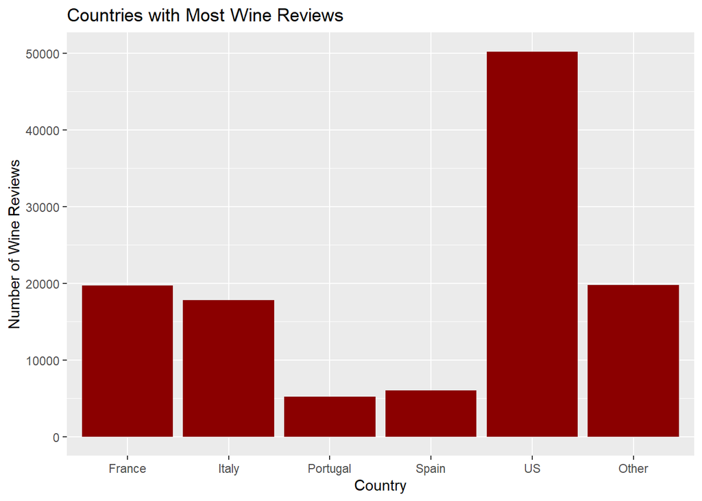

```r
wine_ratings %>%
  mutate(country = fct_lump(country,5)) %>%
  ggplot(aes(country)) +
  geom_bar(fill = "darkred") +
  labs(x = "Country", y = "Number of Wine Reviews",
       title = "Countries with Most Wine Reviews")
```

## What are the TOP-10 most reviewed grape varieties?

```r
wine_ratings %>%
  count(variety, sort = TRUE)
```

```
## # A tibble: 702 x 2
##    variety                      n
##    <fct>                    <int>
##  1 Pinot Noir               12191
##  2 Chardonnay               10778
##  3 Cabernet Sauvignon        8822
##  4 Red Blend                 8210
##  5 Bordeaux-style Red Blend  6380
##  6 Riesling                  4758
##  7 Sauvignon Blanc           4542
##  8 Syrah                     3822
##  9 Rosé                      3214
## 10 Merlot                    2887
## # ... with 692 more rows
```

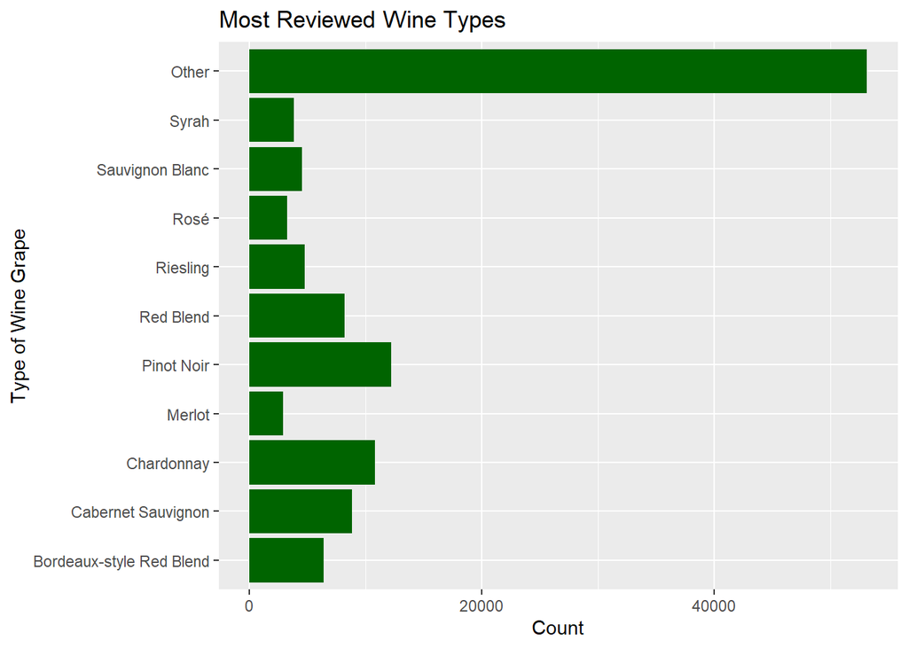

```r
wine_ratings %>%
  filter(!is.na(variety)) %>%
  mutate(variety = fct_lump(variety, 10)) %>%
  ggplot(aes(variety)) +
  geom_bar(fill = "darkgreen") +
  coord_flip() +
  labs(x = "Type of Wine Grape", y = "Count",
       title = "Most Reviewed Wine Types")
```

The dataset has several hundred of fairly-common varietals and some less known niche types. Pinot Noir, Chardonnay and Cabernet Sauvignon are defined to be the most popular wine varieties. Other popular wine grapes include Red Blend, Bordeaux-style Red Blend, Riesling, Sauvignon Blanc, Syrah, Rose and Merlot.

## What is a wine price range?

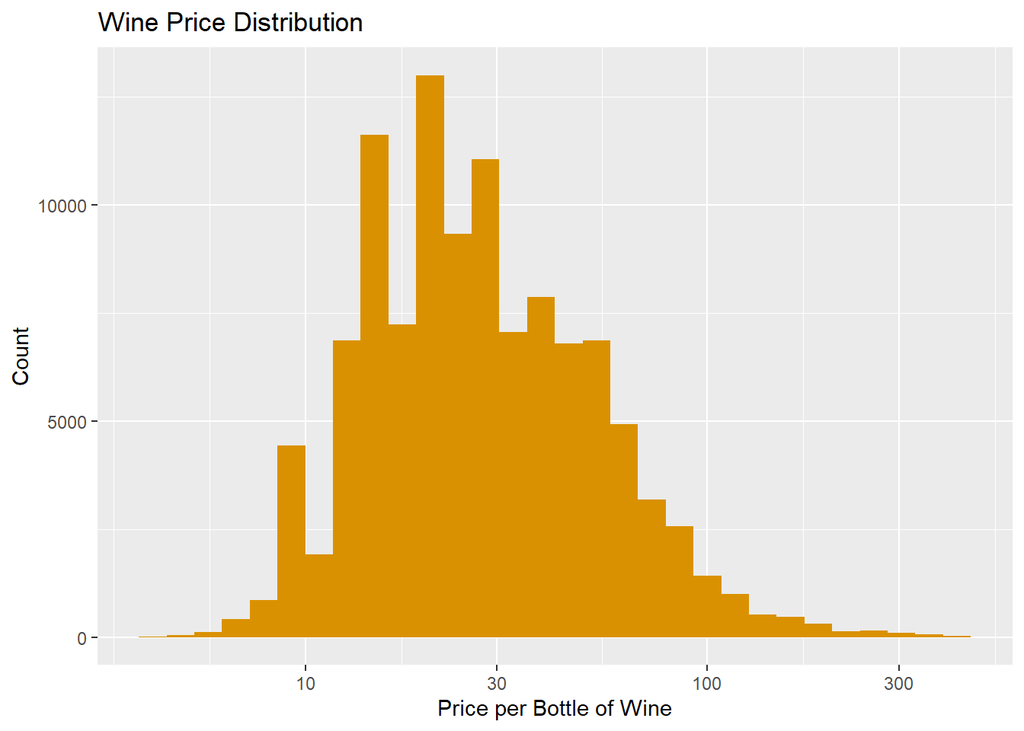

```r
wine_ratings %>%
  filter(price <=400) %>%
  ggplot(aes(price)) +
  geom_histogram(fill = "#DA9101") +
  scale_x_log10() +
  labs(x = "Price per Bottle of Wine", y = "Count",
       title = "Wine Price Distribution")
```

## What is the relation between the price for a bottle of wine and the number of awarded points?

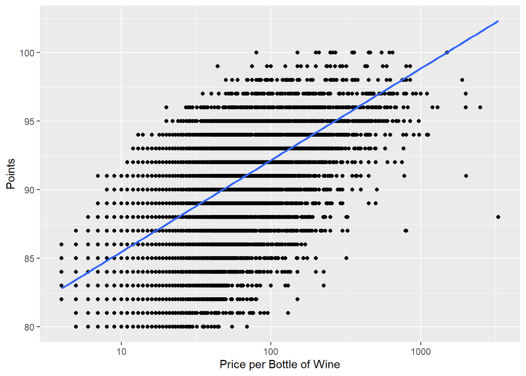

```r
wine_ratings %>%
  ggplot(aes(price, points)) +
  geom_point() +
  geom_smooth(method = "lm", se = FALSE) +
  scale_x_log10() +
   labs(x = "Price per Bottle of Wine", y = "Points")
```

The analysis of the relation between the wine price and awarded number of points showed that wine below $ 10 is unlikely to score more than 85 points, while wine with the price range of $ 800-1000 is likely to receive 95+ points. However, there are many of the wines in the $10 to $100 range that still have “Excellent” ratings of 90 and above within reach. The slope of the line shows a positive relation between the price for a bottle of wine and the number of awarded points.

WineEnthusiast.com says that tastings are conducted blind or in accordance with accepted industry practices, and price is not a factor in assigning scores to wines.

## What is the distribution of various quality categories in each country?

For further analysis, we have to categorize the wines into more defined wine priced categories. The “points” variable has 21 values ranging from 80 to 100. Using 4-point measurement scale we created 5 categories:

1 - [97-100] - Classic. One of the greatest. 2 - [93-96] - Superb. Extremely well made and highly recommended. 3 - [89-92] - Excellent. May offer outstanding value if the price is right. 4 - [85-88] - Very good. Wine with special qualities. 5 - [80-84] - Good. Solid wine, suitable for everyday consumption.

```r
wine_ratings <- wine_ratings %>%
    mutate(category = as.factor(case_when(points > 96 ~ "1",
                              points > 92 ~ "2",
                              points > 88 ~ "3",
                              points > 84 ~ "4",
                              points >= 80 ~ "5"))) %>%
   mutate_if(is.character, factor)
```

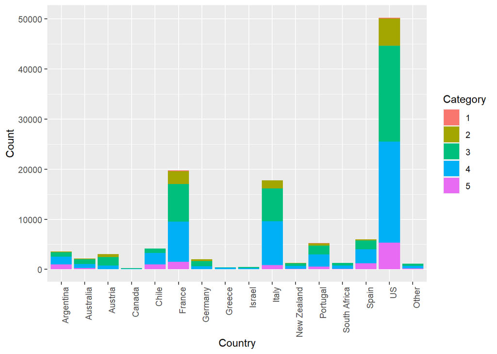

```r
wine_ratings %>%
  mutate(country = fct_lump(country, 15)) %>%
  ggplot(aes(country,fill = category)) +
  geom_bar() +
  theme(axis.text.x = element_text(angle = 90, hjust = 1, line=2.5)) +
  labs(x = "Country", y = "Count", fill = "Category")
```

## ——————————————————————————-

# PREDICTIVE ANALYSIS

## Model 1: Predict wine ratings (in points) by knowing the price, wine variety and country using Linear Regression Model

### Step 1: Splitting the dataset into Training & Testing datasets

```r
library(tidymodels)
wine_ratings_split <- initial_split(wine_ratings)
wine_ratings_train <- training(wine_ratings_split)
wine_ratings_test <- testing(wine_ratings_split)
```

### Step 2: Pre-processing the data

#### 2.1 Setting the recipe & getting the ingredients - recipe()

For this modelling, we will use 4 variables from the dataset.

Since we are predicting wine ratings (in points), points is our **Output variable** and the others are **Input variables**.

```r
wine_ratings_recipe1 <- recipe(points ~ price + country + variety, data = wine_ratings_train)

summary(wine_ratings_recipe1)
```

```
## # A tibble: 4 x 4
##   variable type    role      source
##   <chr>    <chr>   <chr>     <chr>
## 1 price    numeric predictor original
## 2 country  nominal predictor original
## 3 variety  nominal predictor original
## 4 points   numeric outcome   original
```

#### 2.2 Writing the recipe steps - step_xxx()

To ensure the “quality” of data, it should be normalized by “Centering” & “Scalling” - [step_center() & step_scale()]; numeric variables that are closely related should also be removed - [step_corr()].

```r
wine_ratings_recipe1 <- wine_ratings_recipe1 %>%
  step_center(all_numeric(), -all_outcomes()) %>%
  step_scale(all_numeric(), -all_outcomes()) %>%
  step_corr(all_numeric())
```

#### 2.3 Getting ready with the prep - prep()

```r
wine_ratings_prep1 <- prep(wine_ratings_recipe1, training = wine_ratings_train)
```

#### 2.4 Baking the recipe - bake()

```r
wine_ratings_bake1 <- bake(wine_ratings_prep1, wine_ratings_train)
```

### Step 3: Building a model

For this modelling, our Output variable is **Numeric**. Therefore, we’ll be using **Linear Regression Modelling**

```r
model1 <- lm(points ~ price + country + variety, data = wine_ratings_bake1)

summary(model1)
```

```
##
## Call:
## lm(formula = points ~ price + country + variety, data = wine_ratings_bake1)
##
## Residuals:
##     Min      1Q  Median      3Q     Max
## -86.397  -1.777   0.028   1.904  10.377
##
## Coefficients: (2 not defined because of singularities)
##                                             Estimate Std. Error t value
## (Intercept)                                87.570475   1.900853  46.069
## price                                       1.118293   0.009809 114.005
## countryArmenia                             -0.002051   3.290817  -0.001
## countryAustralia                            1.756016   0.101329  17.330
## countryAustria                              3.755807   0.117078  32.080
## countryBosnia and Herzegovina               1.050545   3.290817   0.319
## countryBrazil                              -1.327124   0.474588  -2.796
## countryBulgaria                             2.041772   0.284131   7.186
## countryCanada                               2.864041   0.229525  12.478
## countryChile                                0.233735   0.082034   2.849
## countryChina                                2.368045   2.712746   0.873
## countryCroatia                              2.056270   0.602268   3.414
## countryCyprus                               2.369958   1.901064   1.247
## countryCzech Republic                       1.134908   1.245587   0.911
## countryEngland                              4.785667   0.417785  11.455
## countryFrance                               1.971651   0.070818  27.841
## countryGeorgia                              2.373312   0.622990   3.810
## countryGermany                              2.582960   0.111418  23.183
## countryGreece                               0.975241   0.230046   4.239
## countryHungary                              2.286404   0.457395   4.999
## countryIndia                                4.263593   1.100814   3.873
## countryIsrael                               2.029092   0.159982  12.683
## countryItaly                                2.184522   0.078715  27.752
## countryLebanon                              1.309116   0.637210   2.054
## countryLuxembourg                           2.439066   1.209449   2.017
## countryMacedonia                           -0.218294   1.345789  -0.162
## countryMexico                              -1.359932   0.383985  -3.542
## countryMoldova                              1.278814   0.440449   2.903
## countryMorocco                              2.430227   0.637402   3.813
## countryNew Zealand                          1.838716   0.111323  16.517
```

[output cut: 1351 more lines]

```
## varietyYapincak                            0.214900
## varietyZibibbo                             0.952351
## varietyZierfandler                         0.887665
## varietyZierfandler-Rotgipfler              0.876808
## varietyŽilavka                             0.737779
## varietyZinfandel                           0.456867
## varietyZlahtina                            0.132410
## varietyZweigelt                            0.195452
## ---
## Signif. codes:  0 '***' 0.001 '**' 0.01 '*' 0.05 '.' 0.1 ' ' 1
##
## Residual standard error: 2.686 on 82194 degrees of freedom
##   (6199 observations deleted due to missingness)
## Multiple R-squared:  0.2551, Adjusted R-squared:  0.2488
## F-statistic: 40.73 on 691 and 82194 DF,  p-value: < 2.2e-16
```

### Step 4: Evaluating the model

**P-value** of the coefficients shows how significant the variable is. *** means that the ‘price’ predictor is very meaningful for our model. However, P-value varies from country to country from no * (not meaningful) to *** (very meaningful).

## ——————————————————————————-

## Model 2: Predict a country based on the type of wine grape and average rating of wine produced in that country using Classification Model - ‘randomForest’

### Because the model cannot handle categorical predictors with more than 53 categories, we need to use fct_lump() to choose 50 categories of the “variety” variable that is used in this model.

```r
wine_ratings <- wine_ratings %>%
  mutate(variety = fct_lump(variety, 50))
```

### Step 1: Splitting the dataset into Training & Testing datasets

```r
wine_ratings_split <- initial_split(wine_ratings)
wine_ratings_train <- training(wine_ratings_split)
wine_ratings_test <- testing(wine_ratings_split)
```

### Step 2: Pre-processing the data

#### 2.1 Setting the recipe & getting the ingredients - recipe()

For this modelling, we will use 2 variables from the dataset.

Since we are predicting a country, country is our **Output variable** and the other variable is **Predictor**.

```r
wine_ratings_recipe2 <- recipe(country ~ category + variety, data = wine_ratings_train)

summary(wine_ratings_recipe2)
```

```
## # A tibble: 3 x 4
##   variable type    role      source
##   <chr>    <chr>   <chr>     <chr>
## 1 category nominal predictor original
## 2 variety  nominal predictor original
## 3 country  nominal outcome   original
```

#### 2.2 Writing the recipe steps - step_xxx()

To ensure the “quality” of data, it should be normalized by “Centering” & “Scalling” - [step_center() & step_scale()]; numeric variables that are closely related should also be removed - [step_corr()].

```r
wine_ratings_recipe2 <- wine_ratings_recipe2 %>%
  step_center(all_numeric(), -all_outcomes()) %>%
  step_scale(all_numeric(), -all_outcomes()) %>%
  step_corr(all_numeric())
```

#### 2.3 Getting ready with the prep - prep()

```r
wine_ratings_prep2 <- prep(wine_ratings_recipe2, training = wine_ratings_train)
```

#### 2.4 Baking the recipe - bake()

```r
wine_ratings_bake2 <- bake(wine_ratings_prep2, wine_ratings_train)
```

### Step 3: Building a model

For this modelling our **Output** variable is a **Factor**. Therefore, we’ll be using randomForest().

```r
library(randomForest)
wine_ratings_bake2 <- droplevels(wine_ratings_bake2)

model2 <- randomForest(country ~ category + variety, data = wine_ratings_bake2, na.action = na.omit)

print(model2)
```

```
##
## Call:
##  randomForest(formula = country ~ category + variety, data = wine_ratings_bake2,      na.action = na.omit)
##                Type of random forest: classification
##                      Number of trees: 500
## No. of variables tried at each split: 1
##
##         OOB estimate of  error rate: 39.47%
## Confusion matrix:
##                        Argentina Armenia Australia Austria
## Argentina                      1       0         0       0
## Armenia                        0       0         0       0
## Australia                      0       0       220       0
## Austria                        0       0         1     607
## Bosnia and Herzegovina         0       0         0       0
## Brazil                         0       0         0       0
## Bulgaria                       0       0         0       0
## Canada                         0       0         0       0
## Chile                          0       0         2       0
## Croatia                        0       0         0       0
## Cyprus                         0       0         0       0
## Czech Republic                 0       0         0       0
## Egypt                          0       0         0       0
## England                        0       0         0       0
## France                         0       0         0       0
## Georgia                        0       0         0       0
## Germany                        0       0         0       0
## Greece                         0       0         0       0
## Hungary                        0       0         0       0
## India                          0       0         3       0
## Israel                         0       0         7       0
## Italy                          0       0         0       2
## Lebanon                        0       0         0       0
## Luxembourg                     0       0         0       0
## Macedonia                      0       0         0       0
## Mexico                         0       0         0       0
## Moldova                        0       0         0       0
## Morocco                        0       0         0       0
## New Zealand                    0       0         0       1
## Peru                           0       0         0       0
```

[output cut: 298 more lines]

```
## Morocco                      0     8   1.0000000
## New Zealand                  0   894   1.0000000
## Peru                         0     8   1.0000000
## Portugal                     0   635   0.3373922
## Romania                      0    51   1.0000000
## Serbia                       0     1   1.0000000
## Slovakia                     0     1   1.0000000
## Slovenia                     0    21   1.0000000
## South Africa                 0   631   1.0000000
## Spain                        0  2148   0.8156672
## Switzerland                  0     2   1.0000000
## Turkey                       0    13   1.0000000
## Ukraine                      0     7   1.0000000
## Uruguay                      0    24   1.0000000
## US                           0 30582   0.1866489
```

## —————————————————————————————————————–

# FINDINGS & CONCLUSION

As per the *Descriptive Analysis*,we have these findings-

1.TOP-5 wine-producing countries : *the US, France, Italy, Spain and Portugal*

2.Pinot Noir, Chardonnay and Cabernet Sauvignon turned out to be the most popular wine varieties. Other popular types of wine include Red Blend (6.8%), Bordeaux-style Red Blend (5.3%), Riesling (4%), Sauvignon Blanc (3.8%), Syrah (3.2%), Rose (2.7%) and Merlot (2.4%).

For *Predictive Analysis*, we have found out-

1.The first model designed to predict wine ratings (in points) by knowing the price, wine variety and country turned out to be *not accurate*. It explains only 25% of the data variability.

One of the limitations of this dataset is that there are a lot more reviews for popular wine varietals (Pinot Noir, Chardonnay and Cabernet Sauvignon), and as a result, it is harder to build an accurate model for less popular types of wine. Another limitation is connected to the US having the highest level of reviewed wine, 42% of total number of reviews, due to the fact that data is derived from the US-based company.

## ——————————————————————————————————————-

# RECOMMENDATIONS

Running a linear regression to predict wine ratings (in points) off the price, wine variety and country resulted in an overall accuracy of only 25%. The classification model performed better resulting in 60% accuracy. In order to improve accuracy of the models, deeper analysis of additional classifiers can be run. For example, wine priced categories can be further defined. Descriptions of individual wines contain different descriptive words, and therefore, word analysis can be done to link these descriptive words together and come up with the model to classify them.